# Vague quantification and object representation in humans vs. Large Vision Language Models

Raquel Montero, Natalia Moskvina, Paolo Morosi, Elena Pagliarini and Evelina Leivada  
Universitat Autònoma de Barcelona

XPrag 2025, 19/09/2025

## Vague quantification in human language

Vague quantifiers display a huge amount of variability. Despite this, psycholinguists and theoretical linguists agree that human quantification is affected/regulated by:

- **Typicality**  
(Tiel and Geurts 2014; Ramotowska et al. 2024, a.o.)

- **Ordered Scales**: <some, many, most, all>  
(Horn 1972; Katsos et al. 2016; Pagliarini et al. 2018; Gotzner and Romoli 2022, a.o.)

- **Cognitive biases**: clustering, size, etc.  
(Krueger 1972; Pauw 2013; Bertamini et al. 2018, a.o.)

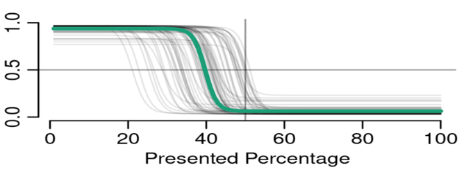

Variation Quantifier *Few* (Ramotowska et al. 2024)

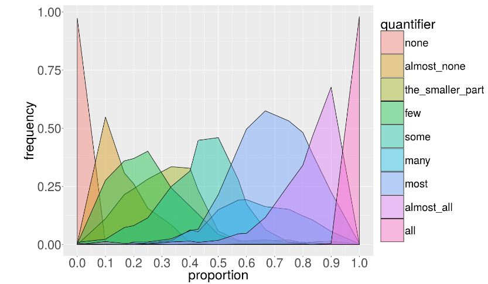

Quantifier Scales (Pezzelle, Bernardi, and Piazza 2018)

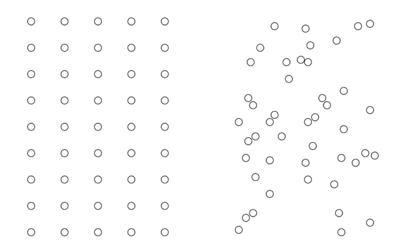

Regular-random illusion (Bertamini et al. 2018)

## Quantification in LVLM: Testoni, Sprott, and Pezzelle (2024)

Study comparing the language used by humans and Large Vision Language Models (LVLMs) when describing images.

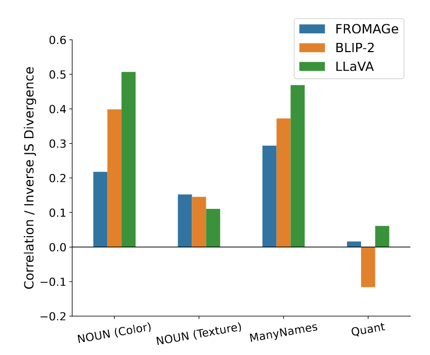

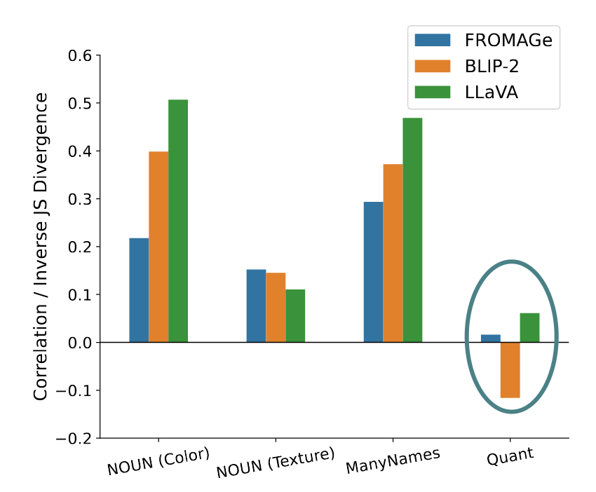

**Conclusion**: models deviated most from humans in the quantifier task.

## Why might models struggle with quantification?

**Hypothesis**: Poor counting skills of the models (Testoni, Sprott, and Pezzelle 2024).

> […] *all models struggle to successfully count how many animals appear in the image. We hypothesize that the reason for the poor performance in assigning quantifiers lies in the quantity estimation and comparison skills of the models.* (Testoni, Sprott, and Pezzelle 2024, 5)

**However**, quantifiers have been argued to use an **approximate number system** that is independent from the **symbolic counting system** (Lidz 2016; Dolscheid et al. 2017; Szymanik, Kochari, and Bremnes 2023).

There might be other reasons (internal or external) that explain the poor performance of the models with quantifiers.

## Research Questions

1. **Why might models struggle with quantification?**
- Failure to replicate human cognitive mechanisms/biases for numerosity estimation
- Model’s internal representations of quantification (ordered scales, typicality, etc.).
2. **Are there differences across different types of models?**

GPT-4o (non-reasoning model) and o4-mini (reasoning model)

3. **Do the same patterns of behavior emerge cross-linguistically?**

## Methodology

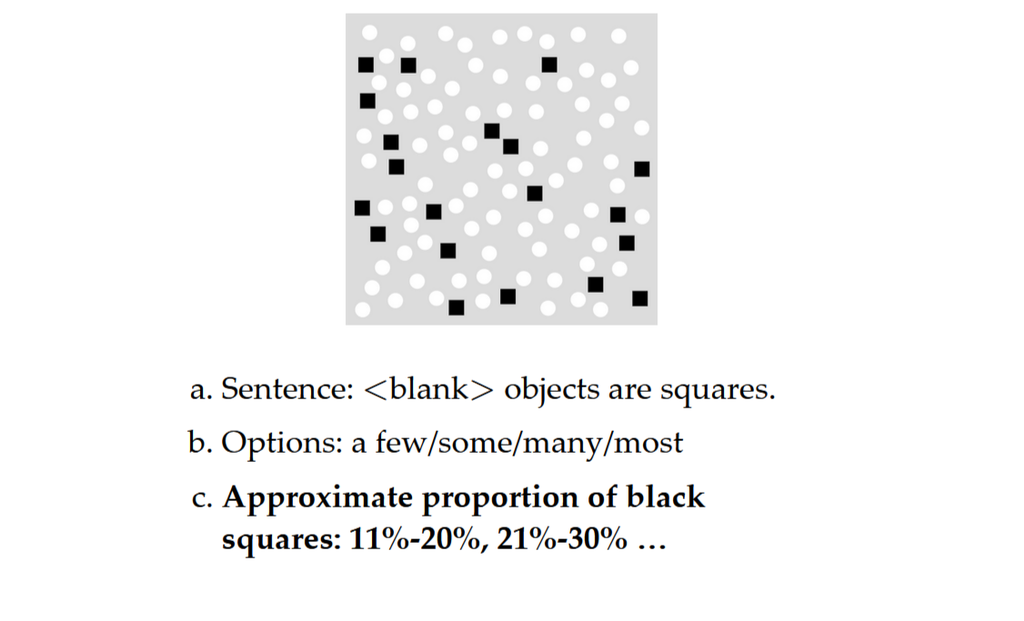

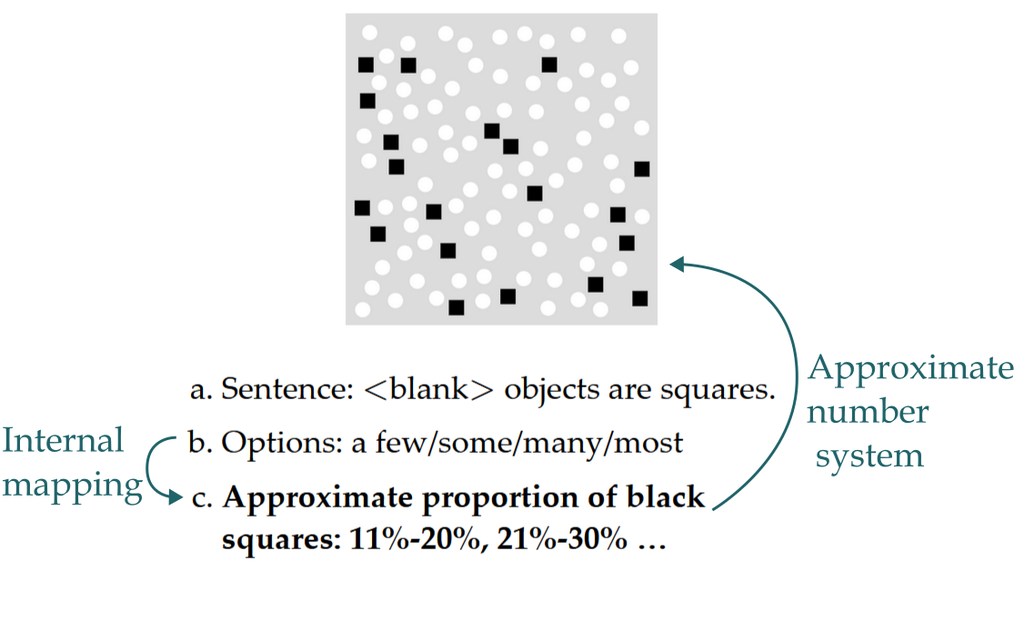

- **Languages**: English, Greek, Russian, Spanish, Italian and Catalan
- **Data collection per language**:

|  | `Participants’ | Method |
| --- | --- | --- |
| Humans | 40 | PCIbex |
| GPT-4o | 40 | openAI API |
| o4-mini | 40 | openAI API |

## Results: internal representations

[interactive chart not shown]

Ordered Scales:  
<a few, some, many, most>$^1$

• GPT-4o: ✘  
• o4-mini$^2$: ✔

Typicality (Mode) and range (IQR):  
• GPT-4o: ✘  
• o4-mini: ✘

Multinomial Regression $\rightarrow$ significant

**Models seem to have problems with the internal representation of quantification.**

1.Catalan data does not follow this exact pattern. 2. Greek deviates from this.

## Internal respresentations in LVLM - embeddings

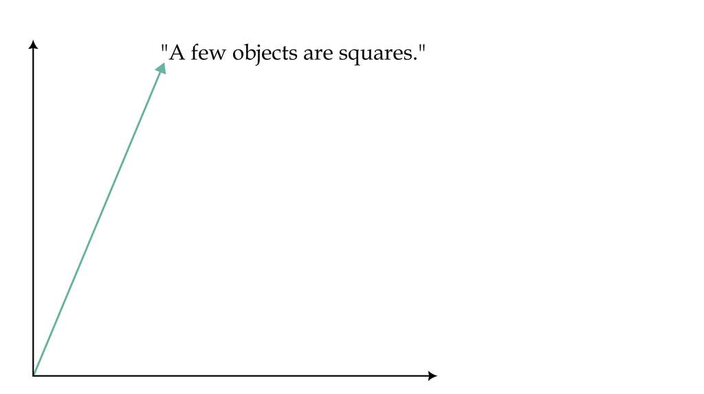

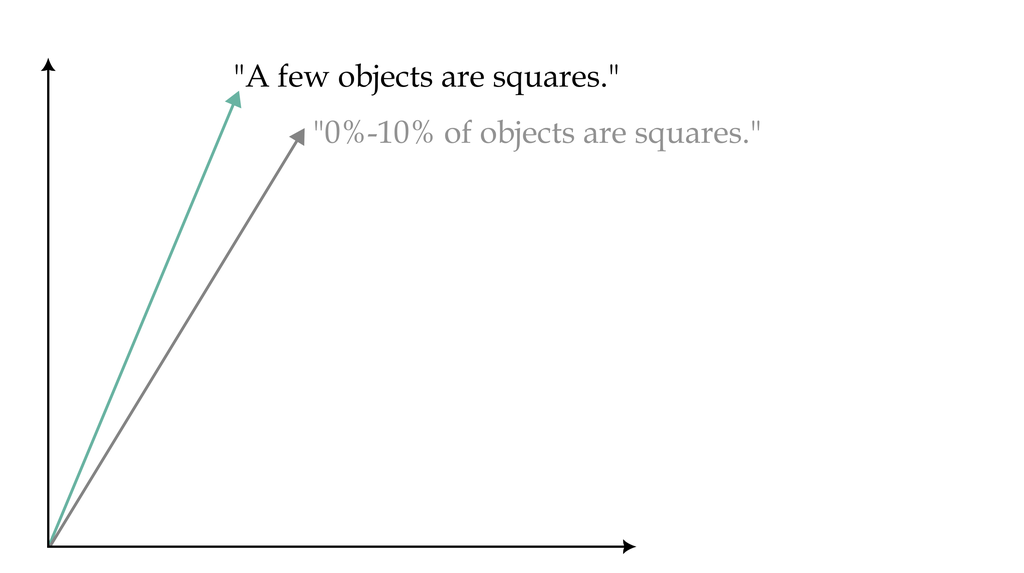

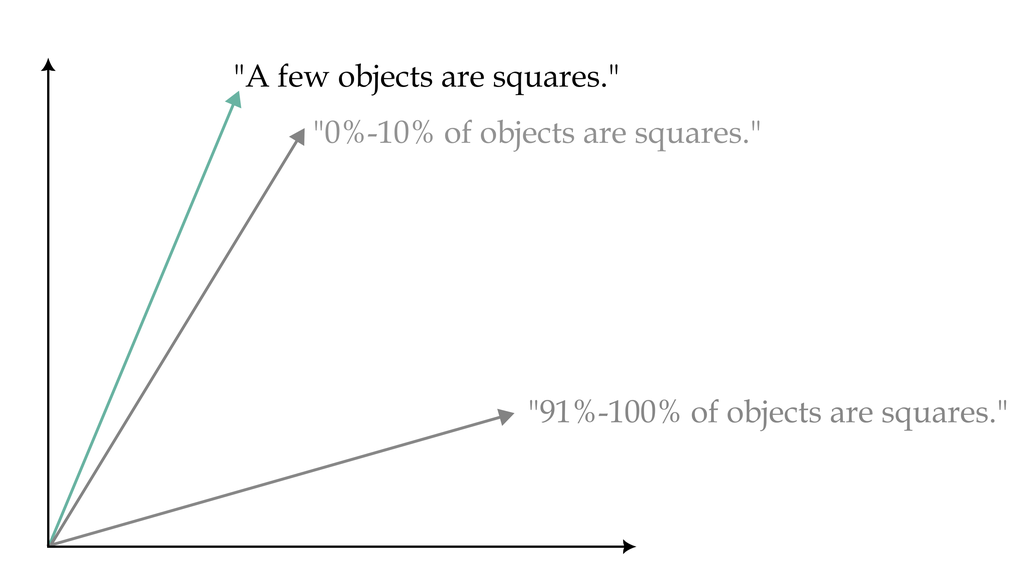

Cosine similarity

$\cos(\vec{q},\vec{p}) = \dfrac{\vec{q}\cdot \vec{p}}{||\vec{q}|| \cdot||\vec{p}||}$  
Gives a number between -1 and 1.  
The closer to 1, the higher the similarity.

## Results: internal respresentations - embeddings

**Model**: text-embedding-3-large $\rightarrow$ only accessible embedding model in OpenAI’s API

[figure not shown]

**Some models face problems with the internal representation of quantification.**

## Internal representations in LVLM - reasoning

Reasoning models are trained via **Reinforcement Learning** (on verifiable problems) to create **long chains of thought** before providing a final answer (OpenAI 2025).

[figure not shown]

Image adapted from Wolfe (2025) and Wei et al. (2022). Simplified explanation of (non)-reasoning models.

**Hypothesis**: given the inter-speaker variability in quantifier usage, these techniques may not be enough to replicate typicality values and ranges of usage.

## Recap

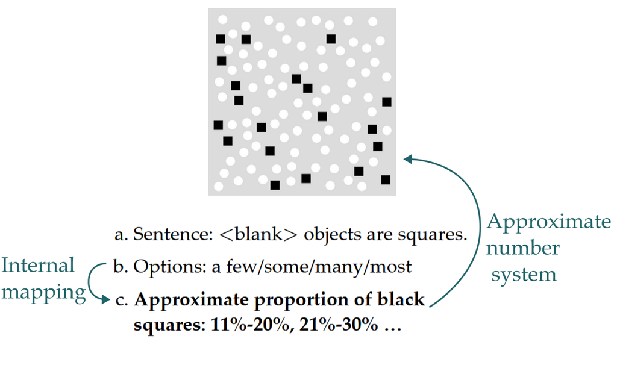

## Results: approximate number system

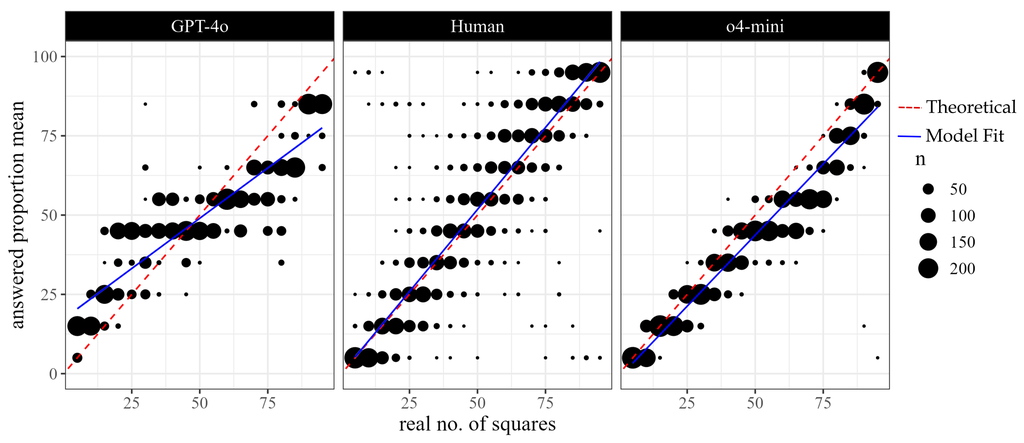

## Conclusions

1. **Why might models struggle with quantification?** $\rightarrow$ **multi-causal**

Models have problems in the internal representation of typicality, range of usage and ordering of scales; and differ from humans in numerosity estimation.

2. **Are there differences across different types of models?** $\rightarrow$ **Yes**

GPT-4o struggles with typicality, range of usage and ordering of scales, while o4-mini seems at least to have captured the ordering of quantifiers in some languages.

3. **Do the same patterns of behavior emerge cross-linguistically?** $\rightarrow$ **Mostly**

Slight differences, particularly with low-resource languages (e.g. in Greek), and cross-linguistic variability is not captured by the models (e.g. Catalan).

## Acknowledgements

Many thanks to M. Teresa Espinal and the members of CLT at UAB for their useful feedback and suggestions.

We also gratefully acknowledge funding from the Spanish National Research Agency (CNS2023-144415); MCIN/AEI/10.13039/501100011033 and the European Union NextGenerationEU/PRTR (Grant RYC2021-033969-I).

# Extra Slides

## Results: overall patterns II

[interactive chart not shown]

## Catalan: quantifiers’ variation

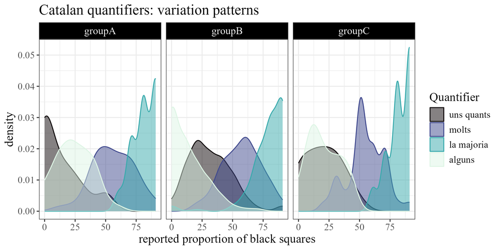

## Quantifiers Selection

| English | Greek | Russian | Spanish | Italian | Catalan |
| --- | --- | --- | --- | --- | --- |
| Most | Τα περισσότερα | большинство | La mayoría | La maggior parte | La majoria |
| Many | Πολλά | многие | Muchos | Molti | Molts |
| Some | Κάποια | некоторые | Algunos | Alcuni | Alguns |
| A few | Λίγα | несколько | Unos pocos | Pochi | Uns quants |
| (Kearns 2017) | (Giannakidou 2012) | (Krasikova 2011) | (Martı́ 2015) | (Crisma 2012) | (Brucart and Rigau 2006) |

## References

Bertamini, Marco, Martin Guest, Giorgio Vallortigara, Rosa Rugani, and Lucia Regolin. 2018. “The Effect of Clustering on Perceived Quantity in Humans (Homo Sapiens) and in Chicks (Gallus Gallus).” *Journal of Comparative Psychology* 132 (3): 280.

Brucart, Josep M, and Gemma Rigau. 2006. “La Quantificació.” In *Gramàtica Del Català Contemporani*, 1517–89. Editorial Empuries.

Crisma, Paola. 2012. “Quantifiers in Italian.” *Handbook of Quantifiers in Natural Language*, 467–534.

Dolscheid, Sarah, Christina Winter, Lea Ostrowski, and Martina Penke. 2017. “The Many Ways Quantifiers Count: Children’s Quantifier Comprehension and Cardinal Number Knowledge Are Not Exclusively Related.” *Cognitive Development* 44: 21–31.

Giannakidou, Anastasia. 2012. “The Landscape of Greek Quantifiers.” *Handbook of Quantifiers in Natural Language*, 285–346.

Gotzner, Nicole, and Jacopo Romoli. 2022. “Meaning and Alternatives.” *Annual Review of Linguistics* 8: 213–34.

Horn, Laurence Robert. 1972. *On the Semantic Properties of Logical Operators in English*. University of California, Los Angeles.

Katsos, Napoleon, Chris Cummins, Maria-José Ezeizabarrena, Anna Gavarró, Jelena Kuvač Kraljević, Gordana Hrzica, Kleanthes K Grohmann, et al. 2016. “Cross-Linguistic Patterns in the Acquisition of Quantifiers.” *Proceedings of the National Academy of Sciences* 113 (33): 9244–49.

Kearns, Kate. 2017. *Semantics*. Bloomsbury Publishing.

Krasikova, Sveta. 2011. “On Proportional and Cardinal ‘Many’.” *Generative Grammar in Geneva* 7: 93–114.

Krueger, Lester E. 1972. “Perceived Numerosity.” *Perception & Psychophysics* 11 (1): 5–9.

Lidz, Jeffrey. 2016. “Quantification in Child Language.”

Martı́, Luisa. 2015. “The Morphosemantics of Spanish Indefinites.” In *Semantics and Linguistic Theory*, 576–94.

Pagliarini, Elena, Cory Bill, Jacopo Romoli, Lyn Tieu, and Stephen Crain. 2018. “On Children’s Variable Success with Scalar Inferences: Insights from Disjunction in the Scope of a Universal Quantifier.” *Cognition* 178: 178–92.

Pauw, Simon. 2013. *Size Matters: Grounding Quantifiers in Spatial Perception*. University of Amsterdam.

Pezzelle, Sandro, Raffaella Bernardi, and Manuela Piazza. 2018. “Probing the Mental Representation of Quantifiers.” *Cognition* 181: 117–26.

Ramotowska, Sonia, Julia Haaf, Leendert Van Maanen, and Jakub Szymanik. 2024. “Most Quantifiers Have Many Meanings.” *Psychonomic Bulletin & Review* 31 (6): 2692–2703.

Szymanik, Jakub, Arnold Kochari, and Heming Strømholt Bremnes. 2023. “Questions about Quantifiers: Symbolic and Nonsymbolic Quantity Processing by the Brain.” *Cognitive Science* 47 (10): e13346.

Testoni, Alberto, Juell Sprott, and Sandro Pezzelle. 2024. “Naming, Describing, and Quantifying Visual Objects in Humans and LLMs.” *arXiv Preprint arXiv:2403.06935*.

Tiel, Bob van, and Bart Geurts. 2014. “Truth and Typicality in the Interpretation of Quantifiers.” In *Proceedings of Sinn Und Bedeutung*, 18:451–68.

Wei, Jason, Xuezhi Wang, Dale Schuurmans, Maarten Bosma, Fei Xia, Ed Chi, Quoc V Le, Denny Zhou, et al. 2022. “Chain-of-Thought Prompting Elicits Reasoning in Large Language Models.” *Advances in Neural Information Processing Systems* 35: 24824–37.

Wolfe, Cameron R. 2025. “Demystifying Reasoning Models.” https://cameronrwolfe.substack.com/p/demystifying-reasoning-models.